# Organizational Decline and Turnaround

Converted from PDF `Trahms-OrganizationalDeclineTurnaround-2013-JOM.pdf` · 31 pages · anchors: page `#pN`, block `#pN-bK`

Page 1

Journal of Management Vol. 39 No. 5, July 2013 1277-1307

DOI: 10.1177/0149206312471390

© The Author(s) 2013 Reprints and permission: http://www. sagepub.com/journalsPermissions.nav

1277

## Organizational Decline and Turnaround: A Review

## and Agenda for Future Research

#### Cheryl A. Trahms

*Texas A&M University*

#### Hermann Achidi Ndofor

*Texas A&M University*

#### David G. Sirmon

*University of Washington–Seattle*

*In the 20 years since the last review on organizational decline and turnaround, the scope of turnaround research has expanded dramatically; however, research on this phenomenon remains empirically and theoretically fragmented. Recent research has incorporated managerial cognition, strategic leadership, and stakeholder management and has identified simultaneous and complex resource-based actions beyond the two-stage model developed in the last review by Pearce and Robbins two decades ago. Thus, herein we build from Pearce and Robbins’ review by cataloguing the past 20 years of empirical evidence related to turnaround, developing a descriptive model of organizational decline and turnaround, and concluding with a theory-based research agenda for organizational decline and turnaround. In doing so, this article summarizes what we know about organizational decline and turnaround, and proposes what we need to study, while providing a theoretical road map to guide this future research.*

*Keywords:* *organizational turnaround; organizational decline; firm failure*

*Acknowledgments: The authors would like to thank our action editor Annette L. Ranft and two anonymous reviewers for their helpful suggestions and advice. We are also deeply grateful for the feedback provided by Vincent Barker III on earlier versions of this manuscript.*

*Corresponding author: Cheryl A. Trahms, Texas A & M University, College Station, TX 77845-4221, USA.*

*E-mail: ctrahms@mays.tamu.edu*

Page 2

1278 Journal of Management / July 2013

Organizational decline occurs when a firm’s performance or resource base deteriorates over a sustained period of time (Bruton, Oviatt, & White, 1994; Weitzel & Jonsson, 1989). Causes of organizational decline originate from external factors, such as gradual changes in the competitive landscape or sudden environmental jolts (Park & Mezias, 2005; Short, Ketchen, Palmer, & Hult, 2007), as well as internal factors, such as operational deficiencies and ineffective resource management (Morrow, Sirmon, Hitt, & Holcomb, 2007). Evidence also suggests that most, if not all, firms experience organizational decline. Schendel and Patton (1976) found that nearly one third of the firms in the S&P 500 in 1976 were experiencing 4 years of declining profitability; while more recently, about half (49.8%) of firms in the S&P 500 index for the year 2010 had experienced more than 3 years of decline within the prior 5 years. In fact, firms in fast-growth industries also experience decline. Ndofor, Vanevenhoven, and Barker (in press) found that over 15% of firms in the software industry during the boom period of 1990 to 1996 experienced organizational decline.

In light of the continued weakness in the global economy, the persistent threat of organizational decline—along with the turnaround processes it often necessitates—is likely to remain a highly relevant concern to managers worldwide. However, the concerns and challenges managers face when executing an organizational turnaround are unique and distinct from those of improving performance in a nondecline situation. First, managers must improve performance in a situation of scarce and dwindling organizational and environmental resources. Next, they do so within a context of increasing stakeholder conflict as different constituents jostle to protect their interests. Finally, despite the imperative for decisive action to turn around performance, managers of declining firms make decisions with diminished managerial discretion as greater supervision by boards and increased restrictions by creditors, bondholders, banks, and suppliers all limit their power.

To hasten the development of our theoretical knowledge of organizational decline and turnaround, this article reviews the related research that has occurred since Pearce and Robbins’ (1993) instrumental review nearly 20 years ago. On the basis of their review of nine articles, Pearce and Robbins proposed a two-stage turnaround model that highlighted the contingencies related to retrenchment and strategic actions in promoting turnaround. However, congruent with several critiques of the two-stage model (e.g., Arogyaswamy, Barker, & Yasai-Ardekani, 1995; Barker & Mone, 1994), our review of the fragmented evidence presented in 40 articles suggests a more complex and dynamic process of turnaround.

In light of this literature’s increasing theoretical and empirical fragmentation over the past two decades, our primary objectives for this review are twofold: (a) to catalogue the empirical work in the decline and turnaround stream since 1993 and (b) to offer a revised descriptive model of turnaround that consolidates these new insights and helps propel a theory-based research agenda. In total, this review shows that although Pearce and Robbins’ (1993) core ideas remain central to the process of turnaround, recent research highlights the role that managerial cognition, strategic leadership, stakeholder management, and more-complex resource-based actions play in turnaround. In light of these extensions, we discuss theories relevant to decline and turnaround, thereby assuaging a key criticism of turnaround research: that this stream is largely phenomenon driven. Specifically, we explore resource orchestration, strategic leadership, and stakeholder theory within the decline and turnaround literature to provide a theory-based program for future decline and turnaround research.

Page 3

Trahms et al. / Organizational Decline and Turnaround 1279

Our review begins with a brief review of Pearce and Robbins’ (1993) model and its critiques, then moves to the review of current research and the expanded model this research supports. We then close with a discussion of how resource orchestration, strategic leadership, and stakeholder theory can help direct future research.

#### **A Brief Review of Pearce and Robbins’ Two-Stage Model**

Pearce and Robbins (1993) reviewed nine key articles upon which they developed a twostage turnaround response model. This model pointed to the importance of retrenchment and strategic actions to promote turnaround. More specifically, they suggested that the nature of the cause of decline—that is, whether it is external or internal (Cameron, Sutton, & Whetten, 1988)—should influence the retrenchment and strategic actions in which the organization engages. *Retrenchment* actions, used synonymously with *operating* actions, are defined as a set of organizational activities undertaken to achieve cost and asset reductions (Michael & Robbins, 1998: 35). Conversely, *strategic* actions are those actions undertaken to change or adjust a firm’s domains and how it competes within those domains (Barker & Duhaime, 1997). With a logic of congruence, it was argued that decline resulting from operating issues (i.e., inefficiencies) requires operating actions (such as downsizing) for recovery, whereas recovery from strategic problems (i.e., misalignment of firms with their environments) requires strategic actions (such as new product introductions). Second, the severity of decline should influence whether cost retrenchment (i.e., increased efficiency) or asset retrenchment (i.e., divestment) is needed; severe decline generally necessitates asset retrenchment. Third, according to this model, turnaround is a two-stage process in which cost or asset retrenchment is followed by strategic actions. Finally, the outcome of the turnaround is not guaranteed but instead could range from failure to significant performance gains.

While very influential, Pearce and Robbins’ (1993) turnaround review has been criticized for its narrow scope and the deterministic nature of its two-stage model. For example, Barker and Mone (1994) argued that retrenchment is not always indispensable to the turnaround process, while Arogyaswamy et al. (1995) suggested that turnaround is not always sequential, beginning with retrenchment and followed by strategic recovery actions. Additionally, empirical work outside the scope but within the time period of their review suggested additional complexities. For example, D’Aveni (1989) found that the structure of the top management team was closely associated with response actions. Moreover, D’Aveni found that asset retrenchment is challenging, in that although declining firms often divest businesses, they frequently fail to divest their weakest units. Thus, both critiques and early work alluded to complexities of turnaround, including the challenges of synchronizing resource-based actions, as well as the role that governance structures play in turnaround. As such, a more comprehensive model will include factors beyond the contingencies of two types of actions.

#### **Organizational Decline and Turnaround: An Extended Model**

We now turn attention toward research in the decline and turnaround literature that has occurred since 1993. We utilize 40 empirical articles, which are summarized in Table 1, to

Page 4

1280

**Table 1**

#### **Empirical Decline and Turnaround Articles, 1993-2012**

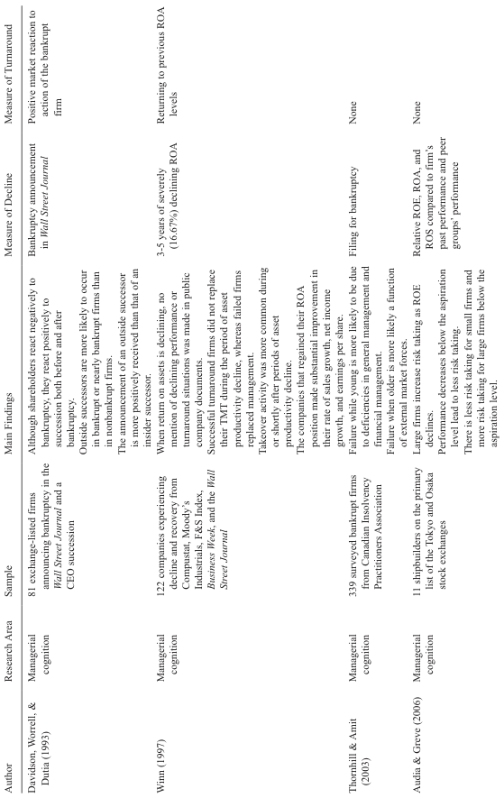

NOTE: complex table shown as an image of the PDF; the text below is a rough machine extraction and may be mis-aligned.

**extracted text (unreliable layout)**

*(continued)*

Page 5

1281

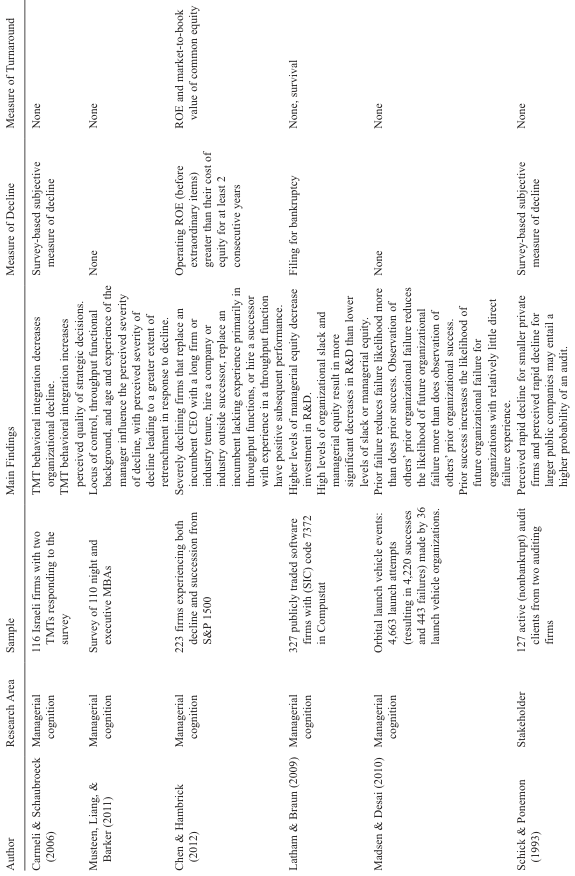

NOTE: complex table shown as an image of the PDF; the text below is a rough machine extraction and may be mis-aligned.

**extracted text (unreliable layout)**

*(continued)*

**Table 1 (continued)**

Page 6

1282

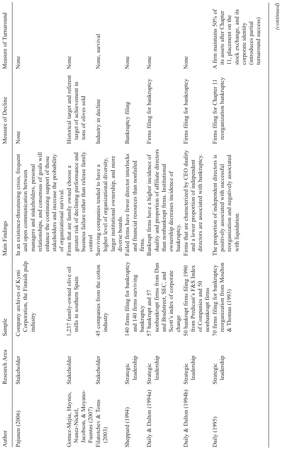

NOTE: complex table shown as an image of the PDF; the text below is a rough machine extraction and may be mis-aligned.

**extracted text (unreliable layout)**

**Table 1 (continued)**

Page 7

1283

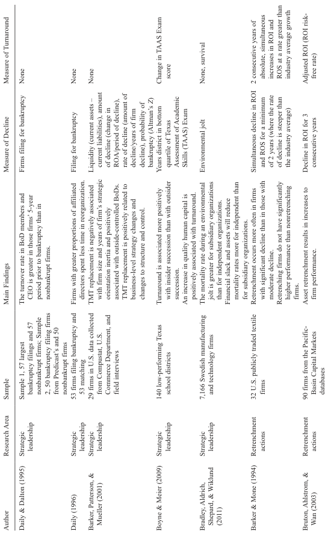

NOTE: complex table shown as an image of the PDF; the text below is a rough machine extraction and may be mis-aligned.

**extracted text (unreliable layout)**

**Table 1 (continued)**

*(continued)*

Page 8

1284

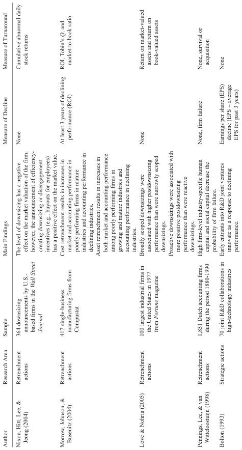

NOTE: complex table shown as an image of the PDF; the text below is a rough machine extraction and may be mis-aligned.

**extracted text (unreliable layout)**

**Table 1 (continued)**

*(continued)*

Page 9

1285

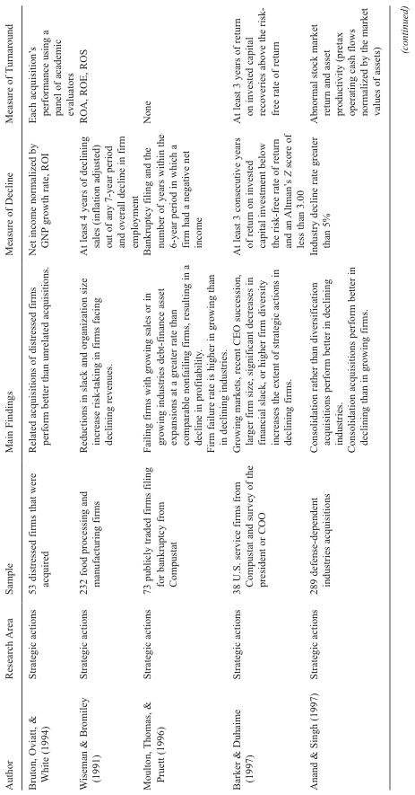

NOTE: complex table shown as an image of the PDF; the text below is a rough machine extraction and may be mis-aligned.

**extracted text (unreliable layout)**

**Table 1 (continued)**

Page 10

1286

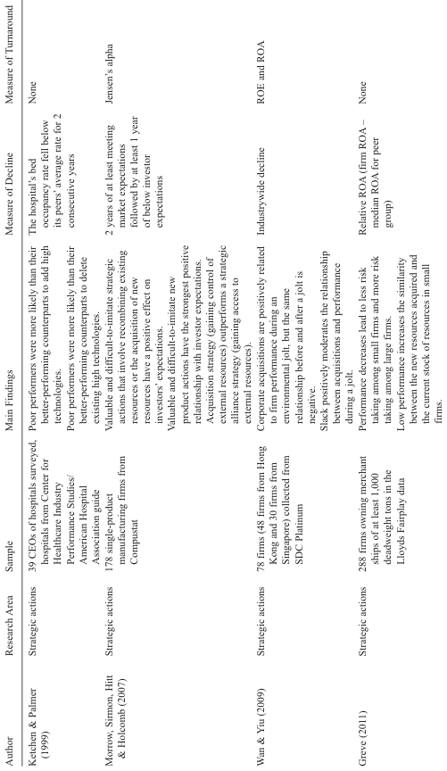

NOTE: complex table shown as an image of the PDF; the text below is a rough machine extraction and may be mis-aligned.

**extracted text (unreliable layout)**

**Table 1 (continued)**

*(continued)*

Page 11

1287

Author Research Area Sample Main Findings Measure of Decline Measure of Turnaround

Ndofor, Vanevenhoven,

& Barker (in press) Strategic actions 114 software firms in decline (36 successful turnarounds,

78 nonturnarounds)

New product introductions, strategic

alliances, and acquisitions will be

positively related to performance

turnarounds for firms declining in a

munificent industry. Layoffs (cost

retrenchment), asset reduction (asset

retrenchment), and asset reduction

(product withdrawal from the market) will

be negatively related to performance

turnaround for firms declining in a

munificent industry.

2 consecutive years of decline after 1 year of 5%

ROA, with a negative net

income in decline Year 2

2 years of increasing ROA after the 2 declining years

of ROA and maintaining

positive ROA by at least

the 6th year after the base

year before decline

Moulton & Thomas

(1993) Outcomes of

turnaround 73 publicly traded firms filing for bankruptcy from

Compustat database

Firms that failed reorganization and were

liquidated were smaller in total assets

prior to reorganization and experienced a

greater number of years with negative net

income in the 6 years prior to bankruptcy

filing than those firms that were successful

or partially successful at reorganization.

Firms filing for Chapter 11

reorganization bankruptcy A firm maintains 50% of

its assets after Chapter

11, placement on the stock exchange, and its

corporate identity

(introduces partial

turnaround success)

*Note*: This table reflects the order in which the research areas are presented in the extended model of turnaround. TMT = top management team; ROA = return on assets; ROE = return on

equity; ROS = return on sales; ROI = return on investment; BoD = board of directors.

**Table 1 (continued)**

Page 12

1288 Journal of Management / July 2013

drive our efforts. These articles were found by examining eight respected journals for articles dealing with decline or turnaround. These journals included *Administrative Science Quarterly, Academy of Management Journal, Journal of Management, Journal of Management Studies, Leadership Quarterly, Management Science, Organization Science*, and *Strategic Management Journal.* These journals were selected either because they are premier journals in the general management field or because they have demonstrated a specific aptitude for decline and turnaround studies. For example, *Leadership Quarterly* and *Journal of Management Studies* have published several key articles in this area that a decline and turnaround review would be remiss to exclude. This table of empirical findings is organized by research area and serves as a basis for the model of organizational decline and turnaround presented in this review. The table highlights the empirical findings as well as sample and operationalization issues of interest to researchers.

Foreshadowing our discussion, Figure 1 presents a graphic representation of our extended turnaround model based on the aforementioned articles. As seen in the model, the literature has mirrored early forerunners to explore managerial cognition, strategic leadership, and stakeholder management as well as richer and more complex resource-based actions. We utilized lighter font and italics to identify elements in the model that are found in Pearce and Robbins’ (1993) two-stage model, while the nonitalicized, dark fonts indicate new additions based on the review of the literature. This helps illustrate the contributions that the recent

**Figure 1 Model of Organizational Decline and Turnaround**

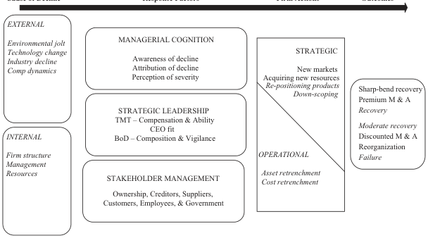

NOTE: figure/graphic rendered as an image from the PDF; its content is not machine-readable text. Caption (if any) follows as the next block.

**text found inside the figure**

STRATEGIC LEADERSHIP TMT – Compensation & Ability

CEO fit BoD – Composition & Vigilance

STRATEGIC

New markets Acquiring new resources

*Re-positioning products*

*Down-scoping*

*OPERATIONAL*

*Asset retrenchment Cost retrenchment*

*EXTERNAL*

*Environmental jolt Technology change Industry decline Comp dynamics*

*INTERNAL*

*Firm structure Management Resources*

Sharp-bend recovery Premium M & A *Recovery*

*Moderate recovery* Discounted M & A Reorganization *Failure*

MANAGERIAL COGNITION

Awareness of decline Attribution of decline Perception of severity

STAKEHOLDER MANAGEMENT

Ownership, Creditors, Suppliers, Customers, Employees, & Government

**Cause of Decline Response Factors Firm Actions Outcomes**

*Note*: Italicized constructs represent components from Pearce and Robbins (1993).

Page 13

Trahms et al. / Organizational Decline and Turnaround 1289

empirical research has made to our understanding of turnaround. It is worth noting that although our discussion flows from left to right across the model, organizational turnaround is an iterative process that can have many feedback loops.

*Causes of Decline*

The conceptualized sources of decline remain rooted in the stream’s foundational work. Cameron et al. (1988) proposed a two-part definition of decline: Decline occurs when an organization’s adaptation or alignment with its niche or domain deteriorates (external causes) or when the firm’s resources constrict, resulting in the deterioration of performance (internal causes). While the sources of decline are well accepted, research on the causes of decline continues.

*External factors.* Research examining external causes of organizational decline focused on changes in industry and general environment factors (Short et al., 2007). Such changes included environmental jolts (Park & Mezias, 2005), technological changes (Dowell & Swarminathan, 2006), industry decline, and competitive dynamics (van Witteloostuijn, 1998). The concept of “environmental jolt” differentiates difficult-to-foresee external events that result in potentially detrimental disruption of the organization from more subtle or incremental changes in the environment (Billings, Milburn, & Schaalman, 1980; Park & Mezias, 2005). Sudden and discontinuous change in an environment may render existing firm strategies ineffective and therefore result in organizational decline (Meyer, 1982; Wan & Yiu, 2009). New, disruptive technologies (Christensen, 1997) fundamentally alter the value chain and key success factors for an industry (Tushman & Anderson, 1986). Demographic changes, changes in product technologies, and the creation of new substitutes can lead to decline in a firm’s industry and subsequently to organizational decline (Grinyer & McKiernan, 1990). Finally, competitive pressures from other firms in the industry that result in more intense rivalry (Grinyer & McKiernan, 1990) can also send a firm into organizational decline (van Witteloostuijn, 1998).

*Internal factors.* The strategic-fit literature (Porter, 1980) and work related to contingency theory (Lawrence & Lorsch, 1968; Pennings, 1992) argued that organizational performance results from the alignment between a firm, its resources, and the environment. If a firm were poorly aligned with the environment, even if this environment were munificent, the firm would face performance losses, thereby leading to decline (Zajac, Kraatz, & Bresser, 2000).

Structural characteristics of an organization, such as size and operating procedures, influence the success of the firm in the long term. Organizational theory has noted that the mortality rates of firms decline with increased size (Hannan & Freeman, 1989; Sutton 1997). However, large firms can suffer from routinization that limits flexibility and fosters inertia, leading to environmental maladaptation (Cyert & March, 1963). Additionally, ineffective top management team interactions or policies can lead to organizational decline. For example, inaction or actions that use resources ineffectively (Schendel, Patton, & Riggs, 1976), such

Page 14

1290 Journal of Management / July 2013

as reducing R&D investments (Johnson, 1996) or targeting acquisitions that lack complementarities (Hitt, Harrison, & Ireland, 2001), can lead to decline.

*Response Factors*

The next section of the model introduces the response factors to decline. Although these factors of managerial cognition, strategic leadership, stakeholders, and actions were alluded to in research at the time of the last review, their empirical examination has started in earnest over the past two decades. They therefore expand Pearce and Robbins’ (1993) model to illustrate a more detailed turnaround process.

*Managerial cognition.* The first aspect of a firm’s response to decline, managerial cognition, accounts for how the top management team (TMT) perceives and interprets the factors that cause decline; as such, it forms the interface between causes of organizational decline and the actions organizations take to reverse it. High-quality, value-added decision making by top management depends on accurate perceptions of the environment (Morrow et al., 2007). Three cognitive factors have been examined and found to affect subsequent turnaround actions: awareness of decline, attribution of decline, and perceptions of the decline’s severity.

*Awareness of decline* refers to managers’ formal recognition that the firm is in decline. The timing of decline awareness has been found to be central to triggering actions that can eventually reverse decline (Furrer, Pandian, & Thomas, 2007; Pajunen, 2006). However, Winn (1997) demonstrated that such awareness is not always readily apparent. Specifically, Winn found that declining asset productivity, in the absence of declining sales or profitability, inhibits decline awareness.

Next, *attribution of decline* refers to the causal factors management identifies as responsible for the decline. While leaders of declining firms are often blamed and serve as scapegoats for organizational decline (Cameron, Kim, & Whetten, 1987), they themselves tend to affix blame elsewhere. Barker and Patterson (1996), for example, found that shorter-tenured TMTs were more likely to attribute decline to internal, controllable, and stable factors, and less likely to blame external factors, than were longer-tenured teams.

An accurate *perception of the decline’s severity* is also essential because poor assessment results in ineffective restructuring strategies that fail to engineer a performance turnaround (Sudarsanam & Lai, 2001). Musteen, Liang, and Barker (2011) found that managerial characteristics influence such perceptions. Specifically, they found that executive age and experience, external locus of control, and throughput functional background increase the perception of decline severity, which subsequently increases the extent of retrenchment.

Although research to date has illustrated the importance of managerial cognition on turnaround, there remain many theory-driven opportunities to better understand the effect cognition has on the whole turnaround process. For example, resource orchestration could aid in understanding the interplay between awareness, attribution, and perception of severity of decline, on the one hand, and turnaround actions and outcomes, on the other. Additionally, agency theory and behavioral agency theory allow for further investigation into how characteristics of the board of directors (BoD) and the TMT affect managerial cognition.

Page 15

Trahms et al. / Organizational Decline and Turnaround 1291

*Strategic leadership.* In this section, we focus on research that has examined the effects of the CEO, TMT, and the BoD on the turnaround process. Broadly speaking, the strategic leadership of the firm can act as an impediment or facilitator of turnaround. Specifically, firm turnaround can be affected by the TMT’s compensation and ability, the CEO’s “fit” or suitability for the current context (Chen & Hambrick, 2012), and the composition and vigilance of the BoD.

The turnaround actions of a firm in decline are significantly influenced by the compensation of the TMT. The career risk associated with firm decline and bankruptcy is not attractive to high-quality managers unless they are compensated for taking a risk to their reputation and future employment (D’Aveni, 1990). Thus, executives who are effectively compensated are motivated to take turnaround actions that best meet the goals of the shareholders. However, equity-based compensation (stock options), which results in a stronger alignment between the managers and shareholders in times of organizational growth (Daily, Dalton, & Cannella, 2003), may result in an “all-or-nothing” risk-taking approach for TMTs that see the cash value of their options falling dramatically. Latham and Braun (2009) found that higher equity holdings motivated managers to decrease R&D investment to respond to decline at a greater rate than managers with no equity position, while higher levels of organizational slack strengthened the decrease in investment in R&D by equity-holding managers. Tangentially related research on executive wealth suggests that an executive’s compensation and personal wealth outside the firm may strongly affect strategies such as investment in R&D during decline (Campbell, 2012).

In comparison with what we know about TMT ability and behavior during periods of firm growth (Finkelstein, Hambrick, & Cannella, 2009), we know relatively less about the TMT during decline and turnaround. Indeed, to the extent that managerial deficiencies (e.g., dysfunctional decision-making processes, deteriorating communications across levels, and increased conflict) have caused or precipitated organizational decline (Arogyaswamy et al., 1995), addressing these issues should be fundamental to turning around performance. Carmeli and Schaubroeck (2006), for example, found that TMT behavioral integration affects not only the perception of quality of strategic actions but also organizational survival.

More recent research also indicates that the ability of the CEO to meet firm needs within a turnaround context is important to the outcome. Conflicting evidence remains regarding the need for CEO replacement, and specifically for an outside successor, to facilitate a successful turnaround. Ndofor et al. (in press) found a strong effect of CEO succession on turnaround performance for declining firms in a growth industry. In contrast, Winn (1997) found that firms that successfully turned around from asset productivity decline did not replace their top management, whereas firms that failed to turn around from asset productivity decline did replace management 21.5% of the time. Davidson, Worrell, and Dutia (1993) found that although shareholders react negatively to bankruptcy, they react positively to succession both before and after bankruptcy. Additionally, they found that outside successions, which are more likely to occur in bankrupt or nearly bankrupt firms, are more positively received than insider successions. However, Boyne and Meier (2009) found that the appointment of a superintendent from within a school district was more strongly associated with successful turnaround than an outside successor. Chen and Hambrick (2012) found that installing a new CEO with experience outside the firm and industry to succeed a longer-tenured CEO

Page 16

1292 Journal of Management / July 2013

with no throughput experience improves firm performance. Additionally, longer-tenured CEOs may be less effective in turnaround contexts. These results support the logic that decline among younger firms may be due to deficient managerial knowledge, whereas decline in older firms may be due to ineffective adaptability on the part of management (Thornhill & Amit, 2003).

The evidence above suggests that certain organizational characteristics may themselves be important mitigating factors in turnaround. For example, firm size has been found to influence risk taking during decline, with smaller firms reducing risk and larger firms increasing risk (Audia & Greve, 2006). Furthermore, independent and subsidiary organizations cope differently with decline, especially environmentally dependent decline. Bradley, Aldrich, Shepherd, and Wiklund (2011) found that independent organizations are more resourceful in coping with sudden environmental changes, particularly in the use of financial slack and assets, than subsidiary organizations, despite the subsidiary’s greater access to resources from the parent company.

Research on the relationships between the board and the TMT and within the TMT in the turnaround context is sparse. However, Barker, Patterson, and Mueller (2001) found that the greater the outsider composition of the board, the greater the turnover in the TMT during turnaround. They also found that longer elapsed time since a change in strategy and larger firm size were associated with lower turnover of TMT during turnaround. And as TMT turnover occurs, changes in the firm’s competitive strategy, organizational structure, and controls increase. However, organizational inertia was found to inhibit TMT replacement.

The monitoring role of the board may be crucially important in a crisis situation, such as decline. A vigilant board with a fiduciary responsibility to shareholders may affect how managers negotiate and take action with other stakeholders (Zahra & Pearce, 1989). In fact, greater structural independence of boards (i.e., an outsider-dominated, separate board leadership structure) is likely to play an important role in managers’ turnaround choices because these boards are more willing to remove ineffective executives (including both the CEO and other executives) before a crisis reaches the point of corporate bankruptcy (Daily et al., 2003). However, Tuggle, Sirmon, Reutzel, and Bierman (2010) found that the attention of

Page 17

Trahms et al. / Organizational Decline and Turnaround 1293

the BoD to managerial actions is not as focused before decline as after a decline has been identified.

In summary, decline and turnaround research has begun to investigate the effect of some elements of strategic leadership on organizational turnaround. Much ground, however, remains to be covered. Although this is an important and challenging time for TMTs and BoDs, which are responsible for steering the firm through the turnaround process, we know less about how they interact with one another and within themselves and how those processes influence turnaround actions and outcomes. By directing future research to more theory-driven investigations of strategic leadership in decline and turnaround situations, researchers may better understand this response factor and how agency conditions and mechanisms aid or hinder the attempts at organizational turnaround. Thus, the research agenda for strategic leadership for firms in decline still leaves significant opportunity for further research.

*Stakeholder management.* Stakeholders play a critical role for all firms, and the limited evidence suggests that the importance of their role increases for firms experiencing decline and attempting turnaround. Stakeholders who have the needed resources and are able to control the interaction and resource flows in the network will most likely have a strong influence on the firm’s survival (Pajunen, 2006) and thus the actions the firm takes. Existing stakeholders may provide resources that normally would not be available to a firm that is experiencing decline (Arogyaswamy et al., 1995); or, conversely, they may exacerbate management’s struggle with decline and turnaround. For example, Schick and Ponemon (1993) found that when auditors perceive a firm to be in rapid decline, the probability of an audit is increased. Understanding stakeholders of a declining firm is challenging because evidence suggests that the objectives of stakeholders can change as the firm enters decline and begins turnaround (Pajunen, 2006); however, identifying and influencing the perceptions of the critical stakeholders is essential for firm turnaround (D’Aveni & MacMillan, 1990). Specifically, we focus on the owners, creditors, suppliers, customers, employees, and government of the firm in decline.

The majority of research has focused on ownership, and while ownership could also be categorized under governance, we discuss it here to highlight concerns related to the changing and potentially conflicting objectives of different stakeholders during decline and turnaround. Early work related to ownership in declining firms examined bankruptcy. Daily and Dalton (1994a) found that institutional ownership decreases the incidence of bankruptcy for firms that enter decline because these owners cannot easily liquidate their positions and thus become active participants in the turnaround process. Furthermore, firms that experience successful turnaround tend to have more institutional ownership than those that fail (Filatotchev & Toms, 2003).

Research has identified family and management ownership as particularly relevant to turnaround situations. While firms with higher management ownership reduce R&D expenditures and the availability of slack resources during decline (Latham & Braun, 2009), family ownership has a mixed effect on turnaround strategies. Cater and Schwab (2008), in a case study, noted that traditional family characteristics, such as strong ties to the family firm, internal orientation, altruistic motives, and long-term goal orientation (Sirmon & Hitt, 2003),

Page 18

1294 Journal of Management / July 2013

may in fact influence the implementation of turnaround strategies. Research into family businesses underscores how the objectives of different owners may diverge for stakeholders during decline. Gomez-Mejia, Haynes, Nunez-Nickel, Jacobson, and Moyano-Fuentes (2007) provided evidence that family-owned firms adopt strategies that have significant downside risk and little upside gain (e.g., staying independent rather than joining a co-op) in an attempt to preserve the family’s ownership and firm viability.

Next, creditors wield considerable power over the decision making of firms in distress. Bruton, Ahlstrom, and Wan (2003) found that major creditors to a firm in decline, such as banks and financial institutions, often apply considerable pressure for decisive action, such as the removal of a CEO. Furthermore, firms that have access to organizational slack through banking relationships have better survival rates, as do firms that have more leniency on accounts payable to suppliers (Pajunen, 2006). Financial capital (organizational slack) from suppliers and creditors enables firms to continue day-to-day operations while enacting retrenchment activities and to fund strategic initiatives essential for some turnaround situations.

Managing the perceptions of customers is important for keeping the basic functions of the business running while attempting a turnaround. Firms that maintain present customers during the turnaround may find the time frame in which they can enact turnaround lengthened, because maintaining customers may stem further declines in profitability (Bruton et al., 2003). Equally important is maintaining the idiosyncratic human capital essential to competitive advantage and the high morale needed in a workforce faced with layoffs and downsizing (S. Freeman & Cameron, 1993). Also worthy of note is potential government intervention for those firms deemed “too big to fail.” In such cases, the government renegotiates the contractual disputes between the firm (most recently, in the automobile and financial industries) and several stakeholders, including employees, suppliers, and creditors; and low-interest loans are granted in order to prevent firm failure.

In total, this preliminary evidence suggests that stakeholders play a key role in decline and turnaround scenarios. Indeed, the stakeholder response factor in the model recognizes the importance of management’s acknowledgement of the stakeholders’ interest and influence during the turnaround process. However, given the fragmented empirical examination of the stakeholders within the turnaround setting, this area of research could benefit from the application of stakeholder theory to present a more robust understanding of how the divergent interests and claims of stakeholders are manifested and sorted during decline and how this process affects turnaround outcome.

*Firm Actions*

*Operational actions.* Empirical evidence of the effect of operational actions on turnaround performance has been fragmented, inconsistent, and without much cumulative theory building. Love and Nohria (2005) found that declining industrial firms that proactively downsized, and did so across the board, had better turnaround performance. Similarly, Bruton et al. (2003) found asset retrenchment resulted in improved performance for declining firms. In producing evidence to the contrary, Nixon, Hitt, Lee, and Jeong (2004), however, found the level of downsizing to have a negative impact on firm performance.

Page 19

Trahms et al. / Organizational Decline and Turnaround 1295

*Strategic actions.* The evidence has underlined the critical role of strategic actions in turnaround. Indeed, it is thought that strategic actions are the true driver of long-term performance gains after decline. For example, Morrow and colleagues (2007) found that recombining the firm’s existing stock of resources to create valuable new products, processes, or technologies, as well as acquiring resources through mergers or acquisitions, has a positive effect on organizational recovery. Both of these actions were more important than allying to gain access to new resources.

For example, firms that are early entrants into R&D joint ventures are stimulated to innovate as a response to performance declines (Bolton, 1993). These scholars found that strategic actions increase the firm’s market share and lead to greater survival prospects.

Finally, as is the case for retrenchment, slack plays a role in determining the effect of strategic actions. Specifically, the level of reductions in slack and organization size influences the riskiness of firms’ strategic actions (Greve, 2011; Wiseman & Bromiley, 1991). Additionally, organizational slack affects the resulting performance increases of acquisitions made during environmental jolts (Wan & Yiu, 2009) as well as the decreases in profitability by firms that enact strategic actions, such as asset acquisition with high levels of debt financing (Moulton et al., 1996).

Overall, the past two decades have witnessed an increase in the research examining the effect of retrenchment and strategic actions on turnaround performance. While the findings show a more consistent and positive effect of strategic actions, the effect of retrenchment actions is far from settled. Although Figure 1 lists the potential retrenchment and strategic actions, research indicates that the efficacy of retrenchment and strategic actions may depend on several contingencies, such as industry life cycle and the availability of slack. Additionally, because these actions are not independent of one another, they should be examined for their interactive effects. Furthermore, although researchers have advanced our understanding of firms’ actions in a turnaround situation, little theoretical headway has been made in this area. The addition of resource orchestration to research on firm actions in turnaround provides a theoretical framework by which to examine the contingencies of dynamic actions in the decline and turnaround setting.

*Turnaround Outcomes*

The second issue with turnaround outcomes lies with how to operationalize a successful turnaround. Pearce and Robbins’ (1993) review noted only three outcomes of the turnaround process: recovery, moderate recovery, or liquidation. However, more recent research has extended the conceptualization of turnaround outcomes. Moulton and Thomas (1993) not only found that some firms use bankruptcy as a deliberate reorganizational strategy within

#### **Turnaround: Future Research**

While turnaround research is perceived as largely phenomenon driven, it is important to note that theory can be a source of new discoveries and provide programmatic direction to the research stream. The empirical review helps identify gaps in the literature as well as theories that may be especially relevant in their application to future turnaround research. For example, although the governance literature covers organizational bankruptcy extensively, it fails to address the turnaround process. Whereas stakeholders are addressed within the literature, stakeholder theory remains underutilized. Additionally, the dynamic management of resources remains central to a successful organizational turnaround; however, little research has utilized the theoretical lens of resource orchestration to discuss the synchronization of resource-based actions. And our knowledge of the role of CEOs, TMTs, and BoDs in the turnaround process can be enhanced by utilizing strategic leadership, resource orchestration, or stakeholder theory. As such, we discuss each of these perspectives in the turnaround context. We specifically delineate a future direction of research within organizational decline and turnaround, through the lenses of resource orchestration, strategic leadership, and stakeholder theory. See Table 2.

*Resource Orchestration*

Managing firms in decline necessitates orchestrating resources to synchronize action, such as divestment, rebundling, and deploying resource sets. Resource orchestration suggests that the firm must simultaneously consider retrenchment and recovery actions during a turnaround attempt. Research on resource orchestration has found that a firm’s capability weaknesses often undermine firm performance. Although firms can still achieve a high level of performance by bundling capability weaknesses with strengths, doing so conveys significant risk (Sirmon, Hitt, Arregle, & Campbell, 2010). Thus, effective resource orchestration is vital to turnaround because firms in decline are likely to have capability portfolios replete with weaknesses. For this reason, asset retrenchment activities, such as divestment, need to be accurately focused to avoid losing strengths along with weaknesses. Indeed, Morrow and colleagues (2007) found that turnaround was best accomplished by reconfiguring valuable and rare resources while divesting undifferentiated assets.

Resource orchestration draws upon the conceptual work of resource management (Sirmon, Hitt, & Ireland, 2007) and asset orchestration (Helfat et al., 2007) and is theoretically

**Table 2 Future Research Directions in Organizational Decline and Turnaround**

Resource Orchestration

• How does resource mismanagement serve as a cause of decline for firms? • Does the timing of retrenchment and strategic actions affect the success of turnaround attempts? Do delayed actions always result in negative firm outcomes? • Are there firm decline contexts in which the relative value of gaining access to resources differs from the exploitation of existing firm resources? • How does management cognition affect the choice of resource orchestration actions? • How does management manage resource liabilities and core rigidities when trying to effect change within the declining firm?

Strategic Leadership

• How do the board of directors’ composition and governance mechanisms affect turnaround actions and outcomes? • Do absent or ineffective governance mechanisms exacerbate the severity of decline? • How does top management team (TMT) compensation affect turnaround actions and outcomes? • How do TMT composition, heterogeneity, and fault lines affect the decision-making process during decline situations? • In cases of CEO turnover during decline, what attributes and experiences of a new CEO are most likely to affect turnaround outcome? • How do executive aspirations and incentives affect decision making of CEOs and TMTs facing organizational decline?

Stakeholder

• What factors affect the interaction of stakeholders during periods of organizational decline? • What motivates stakeholders to take an active role in the turnaround process? • How do family firms balance the need for survival with socioemotional wealth? • How are power struggles between stakeholders resolved? • How do CEOs leverage relationships with stakeholders to foster support for turnaround attempts?

grounded in the resource-based and dynamic capabilities literatures. Resource orchestration focuses on the actions managers take to effectively utilize the firm’s resources through structuring the firm’s resource portfolio, bundling resources into capabilities, and leveraging the capabilities for value creation (Sirmon, Hitt, Ireland, & Gilbert, 2011). Although each action is important, it is in synchronizing or orchestrating the leadership’s resources management actions that value is added in positive firm outcomes.

Resource orchestration allows for the investigation of simultaneous retrenchment and strategic actions or the configuration of actions that best fits with a decline situation. Indeed, given the centrality of resource-based performance arguments in management research, it is surprising that so little turnaround research has examined how the management of a firm’s resources during decline (i.e., the divesting of nonessential resources and the reconfiguration, bundling, or acquisition of new resources) and their leveraging in new competitive actions influence performance turnaround.

Cognitive theories could also be combined with resource orchestration to shed further light on the turnaround process. Changes in the cognitive framework of TMTs could influence changes in resource acquisition, bundling, and leveraging activities. For example, Ndofor, Priem, Rathburn, and Dhir (2009) found that changes in the cognitive models of an organization’s managers lead to subsequent changes in relative resource allocation across different areas of the organization.

Finally, there may be resources (factors) that detract from a firm’s ability to generate rent, including the liabilities of the firm (Powell, 2001) or its core rigidities. A firm’s resource liabilities may include lawsuits, poor reputation, negative employee morale, defective inventory, or high quantities of debt. Any of these factors can limit the firm’s ability to turn its performance around. For example, highly leveraged firms will have a resulting decline in income to service debt; but in the absence of organizational slack, a firm may also miss opportunities to create future competitive advantage and forestall impending decline. Furthermore, to the extent that some prescribed turnaround actions, such as downsizing, could create resource liabilities (e.g., negative employee morale), the interaction and feedback effects of turnaround actions on eventual performance need further investigation.

Thus, the future research agenda of turnaround research can encompass a number of different research directions through resource orchestration. Resource orchestration can provide a theoretical lens through which numerous unresolved issues in turnaround research can be examined, such as resource mismanagement as a cause of organizational decline, the interplay of timing between resource retrenchment and strategic actions to turn around performance, and the relative importance of resource-generation actions (such as bundling or reconfiguring) and resource exploitation (such as leveraging) in fostering performance turnaround. Furthermore, future turnaround research can also combine resource orchestration with cognition research to examine how changes in the TMT’s cognitive framework, together with changes in resource orchestration activities, affect the probability of turning around declining performance. Finally, future research can also utilize resource orchestration to examine how managers can deal with resource liabilities and core rigidities in decline situations to successfully turn around performance.

*Strategic Leadership*

As a result of the separation of ownership and control in the modern corporation, there is a divergence of interests between those who run the firm (agents) and the owners. The actions of managers may not always be in the best interests of the owners. These management actions may be motivated by the background and characteristics of the CEO and TMT or by the divergent interests of management. Organizations in decline provide unique situations in which management actions might be accentuated, and the governance mechanisms put in place to align interests may foster (or impede) the turnaround process. Turnaround research has primarily investigated governance mechanisms, either immediately prior to or at the point of bankruptcy (Daily, 1994). For this reason, little evidence is available regarding the effect of strategic leadership on the actions of the firm during the turnaround process itself. Governance mechanisms may have different effects on firms in decline than on firms experiencing growth. This could be a result of restricted management discretion owing to increased board oversight, bankruptcy monitoring, or increasingly divergent goals among shareholders, creditors, boards of directors, and managers.

The BoD plays a role in the hiring and monitoring of the CEO and TMT. Each CEO and TMT has a unique cognitive framework that shapes its attention and interpretation of the environment. The experiences and social interactions unique to individuals or teams shape the differences of cognitive frames (Reger, 1990; Sutcliffe & Huber, 1998). The differences in executives’ cognitive frameworks have been found to influence firm-level strategic behavior (Marcel, Barr, & Duhaime, 2011), specifically, the awareness and speed with which executives respond to organizational challenges (Sharma, 2000; Tripsas & Gavetti, 2000). Thus, either hiring the appropriate CEO and TMT member(s) or deciding to fire a CEO and TMT member(s) may be contingent on the BoD’s responsibility within agency theory. It is essential that the BoD have the aptitude to determine the ability and cognitive frames of the management of a firm in decline and to hire CEOs with the characteristics to successfully manage the turnaround process.

Although research has shown that the unique cognition of the CEO—such as early awareness, attribution of decline, and perceived severity of decline—has a significant influence on the success of turnaround actions, other CEO, TMT, and firm characteristics that affect the timing of management’s awareness of decline and perception of its severity remain unexamined. Furthermore, the accuracy of the CEO’s and TMT’s perceptions may play a key role in the quality of subsequent decision making. Cognition frameworks within strategic leadership research can therefore be used to examine several unresolved areas in turnaround research.

Thus, future research on turnaround in strategic leadership can build on agency theory to examine how TMT and board composition, board monitoring, and TMT compensation during decline influence the actions undertaken and success at turning around performance. Additionally, agency theory can be used to examine the hiring of a new CEO or the poor fit of the present CEO to the firm’s needs within the firm attempting turnaround. Given that cognitive frameworks evolve with the unique experiences of the executives, are executives with prior experience with organizational decline better able to accurately perceive decline and identify its cause and severity? Is a CEO (or management team) with past experience in decline situations better able to deal with decline?

Similarly, behavioral agency theory provides a comprehensive view of managerial risk taking by integrating governance structure, risk, and performance attributes that influence executive behavior (Wiseman & Gomez-Mejia, 1998). This extends agency theory by considering an alternative to the assumption of consistent risk aversion among agents. Executive aspirations, the perceived risk to executive wealth, past and current performance outcomes, and executive incentives all influence the executive’s problem framing (Wiseman & Gomez- Mejia, 1998). These individual influences, in addition to the fiduciary responsibility to shareholders, remain unexamined in the turnaround setting. Is it possible that the some influences encourage a CEO to attempt a turnaround, while other influences encourage the CEO to seek mergers-and-acquisitions solutions to firm decline?

*Stakeholder Theory*

Stakeholder theory argues that managers must consider the goals of both internal stakeholders (e.g., owners, customers, employees, and suppliers) and external stakeholders (e.g., governments, competitors, special-interest groups, and the media) to successfully manage the firm (R. Freeman, 1984). The balancing of stakeholder objectives is instrumental to maintaining access to or control of the resource flows that strongly influence a firm’s survival (Pajunen, 2006). Research on stakeholder theory has noted that management does not pay equal attention to all stakeholders (Laplume, Sonpar, & Litz, 2008).

When firm resources are being depleted, as often occurs when a firm is experiencing organizational decline, stakeholders become more sensitized to their claims on the firm. Managing stakeholder demands, especially when the firm may need more resources from these stakeholders, becomes even more important. Thus, identifying and influencing the stakeholders critical to firm survival during organizational decline are essential to the success of any turnaround attempt. Stakeholders have the potential to significantly affect turnaround actions and subsequent survival of the firm.

Although turnaround literature has acknowledged the influence of stakeholders (Arogyaswamy et al., 1995; D’Aveni & MacMillan, 1990; Rosenblatt, Rogers, & Nord, 1993), it has not examined it extensively. Indeed, stakeholder theory can be used to shed light on many unresolved questions in turnaround research. For example, the objectives of creditors and owners may differ more strongly for firms in decline or attempting a turnaround. Creditors offer liquidity and sources of investment capital, yet they may be less willing to risk further investment, because their position in a liquidation is far more secure than that of owners. Again, creditors’ upside gain and downside risk for further investment differs from owners’. Thus, the similar objective of creditors and owners during growth times— desire for the firm’s success—can clash during crisis. Finally, while no evidence is readily available in a turnaround context, it is likely that management and employees may be far more willing to encourage all stakeholders to assist the firm to maintain a very moderate recovery rather than allow it to fail and have the assets redeployed because of the reputational and wealth effects such a failure would deliver to employees.

In addition, shareholders may not have unitary interests. The ownership structure of a firm may have significant effects on the actions taken during turnaround (Cater & Schwab,

2008). Family firms desiring to maintain socioemotional wealth (Gomez-Mejia et al., 2007) may take risk-averse actions when their firms experience decline. Firms with higher family ownership may be less likely to implement operational decisions that harm family employees or potentially risky changes to the strategy of the firm. Additionally, family management may block the needed management changes necessary to change the cognitive map of the firm. Future research can examine how actions taken by firms with higher management and family ownership affect the outcome of the turnaround process. In addition, future research can focus on activist shareholders who may advocate certain courses of action in order to extract the most rents possible in a decline situation. Thus, building on agency theory (and other governance theories), future research can shed light on questions such as how ownership concentration and type (institutional, management, or family) affect the type of turnaround actions taken, how stakeholders affect the actions of firms in decline, what motivates a stakeholder to become involved in the turnaround process, and how the power plays between competing stakeholders that invariably take place in decline situations will affect outcomes.

Finally, future research on decline and turnaround viewed through the lens of stakeholder theory may shed significant light on the factors that motivate stakeholder involvement in the turnaround process, the power struggles that occur between stakeholders with divergent interests, and management’s ability to leverage relationships to foster support for the turnaround actions. Additionally, stakeholder theory, in conjunction with governance research, may add significantly to the knowledge of the divergent interests between different owners, such as the family firm with both family and nonfamily ownership, in decline situations that must balance socioemotional wealth and profit maximization.

*Operationalization Issues*

Organizational decline and turnaround research could also benefit from better measures of turnaround performance. There are currently no set standards for measuring decline or turnaround. (See Table 1 for recent operationalizations of decline and turnaround.) Some studies have used financial measures such as return on investment (e.g., Robbins & Pearce, 1992), return on equity (e.g., Pearce & Michael, 1997), or ROA. Using financial ratios has, however, been criticized because performance can be manipulated simply by reducing the denominator (Barker & Mone, 1994). For example, ROA could be made to increase simply by shrinking the asset base (as with asset retrenchment) without any increase in actual performance. As a result, other research has used market-based measures of performance, such as Jensen’s alpha, because they capture investors’ expectations of the future cash flows of the firm (Morrow et al., 2007). However, because these are all continuous measures that require the organization to continue to exist and report performance, there is a high degree of selection bias. That is, the measures do not account for attrition of the firms that are unsuccessful in reversing organizational decline and experience organizational failure. A solution to this bias is the subjective binary grouping of decline organizations into turnaround and nonturnaround categories based on their performance and, in the case of attrition, the reason and nature of their exit (Barker & Mone, 1994).

#### **Conclusion**

The study of organizational decline and turnaround has expanded beyond the scope of Pearce and Robbins’ (1993) two-stage model of turnaround. While the new model of decline and turnaround contributes to our understanding of recent expansions of research on this phenomenon, much of the turnaround domain remains uninvestigated. There remains much to learn about the causes and consequences of firm decline, how strategic leadership differs in decline versus growth settings, how incongruent goals between stakeholders shape organizational turnaround decisions, and the nature of the interdependences between retrenchment and strategic actions. We hope this review and model encourage additional theory-driven research into this valuable and impactful area of research.

#### **References**

Anand, J., & Singh, H. 1997. Asset redeployment, acquisitions and corporate strategy in declining industries.

*Strategic Management Journal*, 18: 99-118. Arogyaswamy, K., Barker, V. L., & Yasai-Ardekani, M. 1995. Firm turnarounds: An integrative two-stage model.

*Journal of Management Studies*, 32: 493-525. Audia, P. G., & Greve, H. R. 2006. Less likely to fail? Low performance, firm size, and factory expansion in the

shipbuilding industry. *Management Science*, 52: 83-94. Barker, V. L., & Duhaime, I. M. 1997. Strategic change in the turnaround process: Theory and empirical evidence.

*Strategic Management Journal*, 18: 13-38. Barker, V. L., & Mone, M. A. 1994. Retrenchment: Cause of turnaround or consequence of decline? *Strategic*

*Management Journal*, 15: 395-405. Barker, V. L., & Patterson, P. W. 1996. Top management team tenure and top manager causal attributions at declin-

ing firms attempting turnarounds. *Group & Organization Management*, 21: 304-336. Barker, V. L., Patterson, P. W., & Mueller, G. C. 2001. Organizational causes and strategic consequences of the

extent of top management team replacement during turnaround attempts. *Journal of Management Studies*, 38: 235-269. Billings, R. S., Milburn, T. W., & Schaalman, M. L. 1980. A model of crisis perception: A theoretical and empirical

analysis. *Administrative Science Quarterly*, 25: 300-316.

Bolton, M. K. 1993. Organizational innovation and substandard performance: When is necessity the mother of

innovation? *Organization Science*, 4: 57-75. Boyne, G., & Meier, K. J. 2009. Environmental change, human resources and organizational turnaround. *Journal*

*of Management Studies*, 46: 835-863. Bradley, S., Aldrich, H., Shepherd, D., & Wiklund, J. 2011. Resources, environmental change, and survival:

Asymmetric paths of young independent and subsidiary organizations. *Strategic Management Journal*, 32: 486-509. Bruton, G. D., Ahlstrom, D., & Wan, J. C. 2003. Turnaround in East Asian firms: Evidence from ethnic overseas

Chinese communities. *Strategic Management Journal*, 24: 519-540. Bruton, G. D., Oviatt, B. M., & White, M. A. 1994. Performance of acquisitions of distressed firms. *Academy of*

*Management Journal*, 37: 972-989. Cameron, K. S., Kim, M. U., & Whetten, D. A. 1987. Organizational effects of decline and turbulence.

*Administrative Science Quarterly*, 32: 222-240. Cameron, K. S., Sutton, R. I., & Whetten, D. A. (Eds.). 1988. *Readings in organizational decline: Frameworks,*

*research, and prescriptions*. Cambridge, MA: Ballinger. Campbell, J. T. 2012. *Top management team personal wealth, within-team diversity and the implications for firm-*

*level risk taking*. Unpublished dissertation, Texas A&M University. Carmeli, A., & Schaubroeck, J. 2006. Top management team behavioral integration, decision quality, and organi-

zational decline. *Leadership Quarterly*, 17: 441-453. Cater, J. J., & Schwab, A. 2008. Turnaround strategies in established small family firms. *Family Business Review*,

21: 31-50. Chen, G., & Hambrick, D. C. 2012. CEO replacement in turnaround situations: Executive (mis)fit and its perfor-

mance implications. *Organization Science*, 23: 225-243. Christensen, C. M. 1997. *The innovator’s dilemma: When new technologies cause great firms to fail*. Boston, MA:

Harvard Business School Press. Cyert, R. M., & March, J. G. 1963. *The behavioral theory of the firm*. Englewood Cliffs, NJ: Prentice-Hall. D’Aveni, R. A. 1989. The aftermath of organizational decline: A longitudinal study of strategic and managerial

characteristics in declining firms. *Academy of Management Journal*, 32: 577-605. D’Aveni, R. A. 1990. Top managerial prestige and organizational bankruptcy. *Organization Science*, 1: 121-142. D’Aveni, R. A., & MacMillan, I. C. 1990. Crisis and the content of managerial communications: A study of the

focus of attention of top managers in surviving and failing firms. *Administrative Science Quarterly*, 35: 634-657. Daily, C. M. 1994. Bankruptcy in strategic studies: Past and promise. *Journal of Management*, 20: 263-295. Daily, C. M. 1995. The relationship between board composition and leadership structure and bankruptcy reorgani-

zation outcomes. *Journal of Management*, 21: 1041-1056. Daily, C. M. 1996. Governance patterns in bankruptcy reorganizations. *Strategic Management Journal*, 17: 355-

375. Daily, C. M., & Dalton, D. R. 1994a. Bankruptcy and corporate governance: The impact of board composition and

structure. *Academy of Management Journal*, 37: 1603-1617. Daily, C. M., & Dalton, D. R. 1994b. CEO and director turnover in failing firms: An illusion of change? *Strategic*

*Management Journal*, 16: 393-400. Daily, C. M., & Dalton, D. R. 1995. CEO and director turnover in failing firms: The illusion of change. *Strategic*

*Management Journal*, 16: 393-401. Daily, C. M., Dalton, D. R., & Cannella, A. A., Jr. 2003. Corporate governance: Decades of dialogue and data.

*Academy of Management Review*, 28: 371-382. Davidson, W., Worrell, D., & Dutia, D. 1993. The stock market effects of CEO succession in bankrupt firms.

*Journal of Management*, 19: 517-533. Dowell, G., & Swaminathan, A. 2006. Entry timing, exploration, and firm survival in the early U.S. bicycle indus-

try. *Strategic Management Journal*, 27: 1159-1182. Filatotchev, I., & Toms, S. 2003. Corporate governance, strategy and survival in a declining industry: A study of

UK cotton textile companies. *Journal of Management Studies*, 40: 895-920. Finkelstein, S., Hambrick, D. C., & Cannella, A. A., Jr. 2009. *Strategic leadership: Theory and research on execu-*

*tives, top management teams, and boards*. Oxford, UK: Oxford University Press.

Freeman, R. E. 1984. *Strategic management: A stakeholder approach*. Boston, MA: Pitman. Freeman, S., & Cameron, K. 1993. Organizational downsizing: A convergence and reorientation framework.

*Organization Science*, 4: 10-29. Furrer, O., Pandian, J., & Thomas, H. 2007. Corporate strategy and shareholder value during decline and turn-

around. *Management Decision*, 45: 372-392. Gomez-Mejia, L. R., Haynes, K., Nunez-Nickel, M., Jacobson, K., & Moyano-Fuentes, J. 2007. Socioemotional

wealth and business risks in family controlled firms: Evidence from Spanish olive oil mills. *Administrative Science Quarterly*, 52: 106-137. Greve, H. R. 2011. Positional rigidity: Low performance and resource acquisition in large and small firms. *Strategic*

*Management Journal*, 32: 103-114. Grinyer, P. H., Mayes, D., & McKiernan, P. 1990. The sharp-benders: Achieving a sustained improvement in per-

formance. *Long Range Planning*, 23: 116-125. Grinyer, P. H., & McKiernan, P. 1990. Generating major change in stagnating companies. *Strategic Management*

*Journal*, 11: 131-146. Hannan, M., & Freeman, J. 1989. Setting the record straight on organizational ecology. *American Journal of*

*Sociology*, 95: 425-435. Helfat, C. E., Finkelstein, S., Mitchell, W., Peteraf, M. A., Singh, H., Teece, D. J., & Winter, S. G. 2007. *Dynamic*

*capabilities: Understanding strategic change in organizations*. Malden, MA: Blackwell. Hitt, M. A., Harrison, J. S., & Ireland, R. 2001. *Mergers and acquisitions: A guide to creating value for stakehold-*

*ers*. Oxford, UK: Oxford University Press. Johnson, R. A. 1996. Antecedents and outcomes of corporate restructuring. *Journal of Management*, 22: 439-483. Ketchen, D., & Palmer, T. 1999. Strategic responses to poor organizational performance: A testing of competing

perspective. *Journal of Management*, 25: 683-706. Laplume, A. O., Sonpar, K., & Litz, R. A. 2008. Stakeholder theory: Reviewing a theory that moves us. *Journal of*

*Management*, 34: 1152-1189. Latham, S. F., & Braun, M. 2009. Management risk, innovation, and organizational decline. *Journal of Management*,

35: 258-281. Lawrence, P., & Lorsch, J. 1968. *Organization and environment*. Homewood, IL: Irwin. Love, E. G., & Nohria, N. 2005. Reducing slack: The performance consequences of downsizing by large industrial

firms, 1977-93. *Strategic Management Journal*, 26: 1087-1108. Madsen, P. M., & Desai, V. M. 2010. Failing to learn? The effect of failure and successes on organizational learning

in the global orbital launch vehicle industry. *Academy of Management Journal*, 53: 451-476. Marcel, J. J., Barr, P. S., & Duhaime, I. M. 2011. The influence of executive cognition on competitive dynamics.

*Strategic Management Journal*, 32: 115-138. Meyer, A. 1982. Adapting to environmental jolts. *Administrative Science Quarterly*, 27: 515-537. Michael, S. C., & Robbins, D. K. 1998. Retrenchment among small manufacturing firms during recession. *Journal*

*of Small Business Management*, 36: 35-45. Morrow, J. L., Johnson, R. A., & Busenitz, L. W. 2004. The effects of cost and asset retrenchment on firm perfor-

mance: The overlooked role of a firm’s competitive environment. *Journal of Management*, 30: 271-283. Morrow, J. L., Sirmon, D. G., Hitt, M. A., & Holcomb, T. R. 2007. Creating value in the face of declining perfor-

mance: Firm strategies and organizational recovery. *Strategic Management Journal*, 28: 271-283. Moulton, W. N., & Thomas, H. 1993. Bankruptcy as a deliberate strategy: Theoretical consideration and empirical

evidence. *Strategic Management Journal*, 14: 125-135. Moulton, W. N., Thomas, H., & Pruett, M. 1996. Business failure pathways: Environmental stress and organiza-

tional response. *Journal of Management*, 22: 571-595. Musteen, M., Liang, X., & Barker, V. L. 2011. Personality, perceptions and retrenchment in response to decline:

Evidence from a decision-making study. *Leadership Quarterly*, 22: 926-941. Ndofor, H. A., Priem, R. L., Rathburn, J. A., & Dhir, A. K. 2009. What does the new boss think? How new leaders’

cognitive communities and recent “top-job” success affect organizational change and performance. *Leadership Quarterly*, 20: 799-813. Ndofor, H. A., Vanevenhoven, J., & Barker, V. L. in press. Software firm turnarounds in the 1990s: An analysis of

reversing decline in a growing, dynamic industry. *Strategic Management Journal*.

Nixon, R. D., Hitt, M. A., Lee, H., & Jeong, E. 2004. Market reactions to announcements of corporate downsizing.

*Strategic Management Journal*, 25: 1121-1129. Pajunen, K. 2006. Stakeholder influences in organizational survival. *Journal of Management Studies*, 43(6): 1261-

1288. Park, N. K., & Mezias, J. M. 2005. Before and after the technology sector crash: The effect of environmental

munificence on stock market response to alliances to e-commerce firms. *Strategic Management Journal*, 26: 987-1007. Pearce, J. A., & Michael, S.C. 1997. Marketing strategies that make entrepreneurial firms recession-resistant.

*Journal of Business Venturing*, 12: 301-314. Pearce, J. A., & Robbins, K. D. 1993. Toward improved theory and research on business turnaround. *Journal of*

*Management*, 19: 613-636. Pennings, J. M. 1992. Structural contingency theory: A reappraisal. In B. M. Staw & L. L. Cummings (Eds.),

*Research in organizational behavior* (Vol. 14): 267-309. Greenwich, CT: JAI Press. Pennings, J. M., Lee, K., & van Witteloostuijn, A. 1998. Human capital, social capital, and firm dissolution.

*Academy of Management Journal*, 41: 425-440. Porter, M. E. 1980. *Competitive strategy*. New York, NY: Free Press. Powell, T. C. 2001. Competitive advantage: Logical and philosophical considerations. *Strategic Management*

*Journal*, 22: 875-888. Reger, R. K. 1990. Managerial thought structures and competitive positioning. In A. S. Huff (Ed.), *Mapping stra-*

*tegic thought*: 301-309. Chichester, UK: Wiley. Robbins, D. K., & Pearce, J. A. 1992. Turnaround: Retrenchment and recovery. *Strategic Management Journal*, 13:

287-309. Rosenblatt, Z., Rogers, R. S., & Nord, W. R. 1993. Toward a political framework for flexible management of

decline. *Organization Science*, 4: 76-91. Schendel, D. E., & Patton, G. R. 1976. Corporate stagnations and turnaround. *Journal of Economics and Business*,

28: 263-241. Schendel, D. E., Patton, G. R., & Riggs, J. 1976. Corporate turnaround strategies: A study of profit decline and

recovery. *Journal of General Management*, 3: 3-12. Schick, A. G., & Ponemon, L. A. 1993. The influence of auditors’ perceptions of organizational decline on audit

risk. *Organization Science*, 4: 92-107. Sharma, S. 2000. Managerial interpretations and organizational context as predictors of corporate choice of envi-

ronmental strategy. *Academy of Management Journal*, 43: 681-697. Sheppard, J. P. 1994. Strategy and bankruptcy: An exploration into organizational death. *Journal of Management*,

4: 795-833. Short, J. C., Ketchen, D. J., Palmer, T. B., & Hult, T. 2007. Firm, strategic group, and industry influences on per-

formance. *Strategic Management Journal*, 28: 147-167. Sirmon, D. G., & Hitt, M. A. 2003. Managing resources: Linking unique resources, management and wealth cre-

ation in family firms. *Entrepreneurship Theory and Practice*, 27: 339-358. Sirmon, D. G., Hitt, M. A., Arregle, J. L., & Campbell, J. T. 2010. Capability strengths and weaknesses in

dynamic markets: Investigating the bases of temporary competitive advantage. *Strategic Management Journal*, 31: 1386-1409. Sirmon, D. G., Hitt, M. A., & Ireland, R. D. 2007. Managing firm resources in dynamic environments to create

value: Looking inside the black box. *Academy of Management Review*, 32: 273-292. Sirmon, D. G., Hitt, M. A., Ireland, R. D., & Gilbert, B. A. 2011. Resource orchestration to create competitive

advantage: Breadth, depth and life cycle effects. *Journal of Management*, 37: 1390-1412. Sudarsanam, S., & Lai, J. 2001. Corporate financial distress and turnaround strategies: An empirical analysis.

*British Journal of Management*, 12: 183-199. Sutcliffe, K. M., & Huber, G. P. 1998. Firm and industry as determinants of executive perceptions of the environ-

ment. *Strategic Management Journal*, 19: 793-807. Sutton, J. 1997. Gibrath’s legacy. *Journal of Economic Literature*, 35: 40-59. Thornhill, S., & Amit, R. 2003. Learning about failure: Bankruptcy, firm age and the resource-based view.

*Organization Science*, 14: 497-509.

Tripsas, M., & Gavetti, G. 2000. Capabilities, cognition, and inertia: Evidence from digital imaging. *Strategic*

*Management Journal*, 21: 1147-1161. Tuggle, C. S., Sirmon, D. G., Reutzel, C. R., & Bierman, L. 2010. Commanding board of director attention:

Investigating how organizational performance and CEO duality affect board members attention to monitoring. *Strategic Management Journal*, 31: 946-968. Tushman, M. L., & Anderson, P. 1986. Technological discontinuities and organizational environments.

*Administrative Science Quarterly*, 31: 439-465. van Witteloostuijn, A. 1998. Bridging behavioral and economic theories of decline: Organizational inertia, strategic

competition, and chronic failure. *Management Science*, 44: 501-519. Wan, W. P., & Yiu, D. W. 2009. From crisis to opportunity: Environmental jolt, corporate acquisitions and firm

performance. *Strategic Management Journal*, 30: 791-801. Weitzel, W., & Jonsson, E. 1989. Decline in organizations: A literature integration and extension. *Administrative*

*Science Quarterly*, 34: 91-109. Winn, J. 1997. Asset productivity turnaround: The growth/efficiency challenge. *Journal of Management Studies*,

34: 585-600. Wiseman, R. M., & Bromiley, P. 1991. Risk-return associations: Paradox or artifact? An empirically tested explana-

tion. *Strategic Management Journal*, 12: 231-241. Wiseman, R. M., & Gomez-Mejia, L. R. 1998. A behavioral agency model of managerial risk taking. *Academy of*

*Management Review*, 23: 133-153. Withers, M. C., Corley, K. G., & Hillman, A. J. 2012. Stay or leave: Director identities and voluntary exit from the

board during organizational crisis. *Organization Science*, 23(3): 835-850. Zahra, S. A., & Pearce, J. 1989. Boards of directors and corporate financial performance: A review and integrative

model. *Journal of Management*, 15: 291-334. Zajac, E. J., Kraatz, M. S., & Bresser, R. K. F. 2000. Modeling the dynamics of strategic fit: A normative approach

to strategic change. *Strategic Management Journal*, 21: 429-456.